# Visual Analytics Individual Coursework

## 4 Data Load, Transform and Validate

### Load and Clean Data

```python
import pandas as pd
import matplotlib.pyplot as plt
import numpy as np
import math


import altair as alt
# run the command below if using Altair in Jupyter Notebook
alt.renderers.enable('notebook')
```

```
RendererRegistry.enable('notebook')
```

```python
# 2 functions to load and clean the datasets

def file_spaces(filename,subscript):
# open a .txt file and replace all spaces with single comma and rewrite as subscript + filename
    f = open(filename,'r')
    filedata = f.read()
    f.close()

    temp = filedata.replace("     "," ")
    temp = temp.replace("    "," ")
    temp = temp.replace("   "," ")
    temp = temp.replace("  "," ")
    newdata = temp.replace(" ",",")

    f = open(subscript+filename,'w')
    f.write(newdata)
    f.close()

def file_filter(filename,start_string,end_string,subscript):
    # filter out extraneous lines at start and end of filename
    # rewrite as subscript + filename
    block_of_lines=[]

    with open(filename) as input_data:
        # Skips text before the beginning of the required block:
        for line in input_data:
            if line.find(start_string,0)!=-1:
                break

        output=open(subscript+filename,'w')
        block_of_lines.append(line) # first line

    # Reads text until the end of the block:
        for line in input_data:  # This keeps reading the file
            if line.find(end_string,0) != -1:
                break
            block_of_lines.append(line)

        output.writelines(block_of_lines)

        output.close()
```

```python
#for all available regions, read in the raw data, clean and concatenate into a single df
regions=[
 'Scotland_N',
 'Scotland_W',
 'Scotland_E',
 'England_NW_and_N_Wales',
 'England_SW_and_S_Wales',
 'England_E_and_NE',
 'England_SE_and_Central_S',
 'Midlands',
 'East_Anglia']

df_loadfile=pd.DataFrame()
file='MetofficeRainfall'

for region in regions:
    infile=file + region + ".txt"
    print("cleaning: ",infile)
    subs1="filter_"
    start_string="JAN"
    end_string="2019"
    file_filter(infile,start_string,end_string,subs1) # filter out non-data lines

    infile=subs1+file + region+".txt"
    print("filtering: ",infile)
    subs2="clean_"
    file_spaces(infile,subs2) # format into csv file

    csvfile = subs2+subs1+file+region+".txt"
    print("reading: ",csvfile,"\n")
    df=pd.read_csv(csvfile)
    df["Region"]=region
    #print(df.describe())
    df_loadfile=df_loadfile.append(df)

df_loadfile.head()
```

```
cleaning:  MetofficeRainfallScotland_N.txt
filtering:  filter_MetofficeRainfallScotland_N.txt
reading:  clean_filter_MetofficeRainfallScotland_N.txt

cleaning:  MetofficeRainfallScotland_W.txt
filtering:  filter_MetofficeRainfallScotland_W.txt
reading:  clean_filter_MetofficeRainfallScotland_W.txt

cleaning:  MetofficeRainfallScotland_E.txt
filtering:  filter_MetofficeRainfallScotland_E.txt
reading:  clean_filter_MetofficeRainfallScotland_E.txt

cleaning:  MetofficeRainfallEngland_NW_and_N_Wales.txt
filtering:  filter_MetofficeRainfallEngland_NW_and_N_Wales.txt
reading:  clean_filter_MetofficeRainfallEngland_NW_and_N_Wales.txt

cleaning:  MetofficeRainfallEngland_SW_and_S_Wales.txt
filtering:  filter_MetofficeRainfallEngland_SW_and_S_Wales.txt
reading:  clean_filter_MetofficeRainfallEngland_SW_and_S_Wales.txt

cleaning:  MetofficeRainfallEngland_E_and_NE.txt
filtering:  filter_MetofficeRainfallEngland_E_and_NE.txt
reading:  clean_filter_MetofficeRainfallEngland_E_and_NE.txt

cleaning:  MetofficeRainfallEngland_SE_and_Central_S.txt
filtering:  filter_MetofficeRainfallEngland_SE_and_Central_S.txt
reading:  clean_filter_MetofficeRainfallEngland_SE_and_Central_S.txt

cleaning:  MetofficeRainfallMidlands.txt
filtering:  filter_MetofficeRainfallMidlands.txt
reading:  clean_filter_MetofficeRainfallMidlands.txt

cleaning:  MetofficeRainfallEast_Anglia.txt
filtering:  filter_MetofficeRainfallEast_Anglia.txt
reading:  clean_filter_MetofficeRainfallEast_Anglia.txt
```

|  | Year | JAN | FEB | MAR | APR | MAY | JUN | JUL | AUG | SEP | OCT | NOV | DEC | WIN | SPR | SUM | AUT | ANN | Region |
| --- | --- | --- | --- | --- | --- | --- | --- | --- | --- | --- | --- | --- | --- | --- | --- | --- | --- | --- | --- |
| 0 | 1910 | 184.1 | 142.5 | 101.4 | 191.5 | 109.4 | 59.2 | 105.5 | 157.3 | 62.1 | 101.0 | 183.9 | 162.3 | --- | 402.3 | 322.0 | 347.0 | 1560.1 | Scotland_N |
| 1 | 1911 | 118.1 | 188.2 | 97.7 | 122.3 | 80.8 | 86.1 | 119.3 | 101.4 | 122.2 | 83.4 | 209.3 | 185.9 | 468.6 | 300.8 | 306.7 | 414.9 | 1514.6 | Scotland_N |
| 2 | 1912 | 109.0 | 114.1 | 143.3 | 142.0 | 86.8 | 107.0 | 83.7 | 156.8 | 74.5 | 161.2 | 225.0 | 303.0 | 409.0 | 372.1 | 347.4 | 460.6 | 1706.3 | Scotland_N |
| 3 | 1913 | 90.4 | 119.7 | 182.4 | 99.8 | 96.0 | 123.2 | 38.5 | 52.4 | 80.9 | 130.4 | 245.1 | 191.1 | 513.1 | 378.2 | 214.1 | 456.4 | 1449.9 | Scotland_N |
| 4 | 1914 | 174.0 | 151.8 | 125.3 | 117.2 | 108.0 | 58.7 | 106.9 | 108.9 | 105.3 | 55.4 | 224.8 | 216.7 | 516.9 | 350.4 | 274.6 | 385.4 | 1552.9 | Scotland_N |

### Transform Data

select the required columns: df_subset  
Convert the month headers to ordinal values  
Melt the main table: df_tidy

```python
# some dataset transformations:
# drop columns not required, add month nos, 'melt' the data to a 'tidy' df, rename columns, add decade

df_loadfile.describe() # confirm no null values
df_loadfile.head()
columns=['Year', 'JAN', 'FEB', 'MAR', 'APR', 'MAY', 'JUN', 'JUL', 'AUG', 'SEP',
       'OCT', 'NOV', 'DEC', 'Region']
df_subset=df_loadfile.loc[:, columns]
df_subset.head()
# convert the months to ordinal
month_dict={'JAN': 1, 'FEB': 2, 'MAR': 3,'APR': 4,'MAY': 5,'JUN': 6,'JUL': 7,'AUG': 8,'SEP': 9,'OCT': 10,'NOV': 11,'DEC': 12}
month_dict_disp={1:'JAN' , 2: 'FEB', 3: 'MAR', 4:'APR', 5:'MAY', 6:'JUN', 7:'JUL', 8:'AUG', 9:'SEP', 10:'OCT', 11:'NOV', 12:'DEC'}
df_subset=df_subset.rename(columns=month_dict)
#un-pivot the df
df_tidy=pd.melt(df_subset, id_vars=['Year','Region'], value_vars=[1,2,3,4,5,6,7,8,9,10,11,12])#
col_dict={'variable':'month_no','value':'Rainfall'}
df_tidy=df_tidy.rename(columns=col_dict)
# Add a decade
df_tidy['decade'] = np.floor( (df_tidy['Year'] ) / 10) * 10
df_tidy = df_tidy.astype({"decade": int}).copy() # copy needed?

# check results
df_tidy.head()
```

|  | Year | Region | month_no | Rainfall | decade |
| --- | --- | --- | --- | --- | --- |
| 0 | 1910 | Scotland_N | 1 | 184.1 | 1910 |
| 1 | 1911 | Scotland_N | 1 | 118.1 | 1910 |
| 2 | 1912 | Scotland_N | 1 | 109.0 | 1910 |
| 3 | 1913 | Scotland_N | 1 | 90.4 | 1910 |
| 4 | 1914 | Scotland_N | 1 | 174.0 | 1910 |

```python
# Add a new column to df_tidy with the Rainfall percentile by Region
percentile=100 # number of bins
df_tidy['reg_perc_bin']=999 # new percentile column with default 999 values

for region in df_tidy['Region'].unique():
    df_tidy.loc[df_tidy["Region"]==region,'reg_perc_bin'] = pd.qcut(df_tidy.loc[df_tidy["Region"]==region,"Rainfall"],percentile,labels=False)

# check results
df_tidy.sort_values('Rainfall').tail(20)
#df_tidy['Rainfall'].sum() # make sure no rows lost
```

|  | Year | Region | month_no | Rainfall | decade | reg_perc_bin |
| --- | --- | --- | --- | --- | --- | --- |
| 10015 | 2006 | Scotland_W | 11 | 316.0 | 2000 | 99 |
| 10892 | 2011 | Scotland_N | 12 | 316.2 | 2010 | 99 |
| 1170 | 1990 | Scotland_W | 2 | 318.8 | 1990 | 99 |
| 10830 | 1949 | Scotland_N | 12 | 319.5 | 1940 | 99 |
| 7997 | 1950 | Scotland_W | 9 | 326.7 | 1950 | 99 |
| 10989 | 1999 | Scotland_W | 12 | 327.6 | 1990 | 99 |
| 10265 | 1929 | England_SW_and_S_Wales | 11 | 327.7 | 1920 | 99 |
| 10024 | 2015 | Scotland_W | 11 | 328.4 | 2010 | 99 |
| 11001 | 2011 | Scotland_W | 12 | 331.2 | 2010 | 99 |
| 10896 | 2015 | Scotland_N | 12 | 332.0 | 2010 | 99 |
| 10976 | 1986 | Scotland_W | 12 | 333.0 | 1980 | 99 |
| 10894 | 2013 | Scotland_N | 12 | 335.9 | 2010 | 99 |
| 2042 | 1990 | Scotland_N | 3 | 335.9 | 1990 | 99 |
| 83 | 1993 | Scotland_N | 1 | 339.8 | 1990 | 99 |
| 10018 | 2009 | Scotland_W | 11 | 340.2 | 2000 | 99 |
| 11223 | 2015 | England_NW_and_N_Wales | 12 | 343.4 | 2010 | 99 |
| 11003 | 2013 | Scotland_W | 12 | 344.4 | 2010 | 99 |
| 127 | 1928 | Scotland_W | 1 | 355.7 | 1920 | 99 |
| 10919 | 1929 | Scotland_W | 12 | 362.7 | 1920 | 99 |
| 11005 | 2015 | Scotland_W | 12 | 383.5 | 2010 | 99 |

#### Derive new datasets ready for analysis

Create summary tables for: region, region/year, decile/region

```python
# create Region df
# averages and some rainfall range values
agg_func = {'Rainfall':['mean','median','sum'] }

region_agg = df_tidy.reset_index(drop=False)[['Region','Rainfall']].groupby(['Region']).agg(agg_func)
region_agg.columns = ["_".join(x) for x in region_agg.columns.ravel()]

rain_dict={'low': 70, 'mid': 110, 'high': 150}
rain_dict['low'] # shows 70

region_agg = region_agg.sort_values(by='Rainfall_mean',ascending=False).reset_index()
region_agg['rainfall_rank'] = region_agg.index
region_agg.head(10)
```

|  | Region | Rainfall_mean | Rainfall_median | Rainfall_sum | rainfall_rank |
| --- | --- | --- | --- | --- | --- |
| 0 | Scotland_W | 136.778135 | 126.50 | 178905.8 | 0 |
| 1 | Scotland_N | 129.726300 | 118.35 | 169682.0 | 1 |
| 2 | England_NW_and_N_Wales | 106.086544 | 99.65 | 138761.2 | 2 |
| 3 | England_SW_and_S_Wales | 101.898700 | 94.00 | 133283.5 | 3 |
| 4 | Scotland_E | 92.214679 | 87.30 | 120616.8 | 4 |
| 5 | Midlands | 65.438991 | 61.60 | 85594.2 | 5 |
| 6 | England_SE_and_Central_S | 65.205275 | 59.20 | 85288.5 | 6 |
| 7 | England_E_and_NE | 63.575765 | 60.65 | 83157.1 | 7 |
| 8 | East_Anglia | 51.074924 | 48.30 | 66806.0 | 8 |

```python
# create aggregate tables to use later
agg_func = {'Rainfall':['mean','median','sum'] }
year_region_agg = df_tidy.reset_index(drop=False)[['Year','Region','month_no','Rainfall']].groupby(['Year','Region']).agg(agg_func)
# Flatten column names
year_region_agg.columns = ["_".join(x) for x in year_region_agg.columns.ravel()]
#validate data still correct
year_region_agg.groupby('Region').sum()
year_region_agg.head(9)
```

| Year | Region | Rainfall_mean | Rainfall_median | Rainfall_sum |
| --- | --- | --- | --- | --- |
| 1910 | East_Anglia | 57.775000 | 54.80 | 693.3 |
|  | England_E_and_NE | 66.033333 | 74.00 | 792.4 |
|  | England_NW_and_N_Wales | 110.266667 | 110.85 | 1323.2 |
|  | England_SE_and_Central_S | 72.425000 | 70.05 | 869.1 |
|  | England_SW_and_S_Wales | 118.008333 | 124.20 | 1416.1 |
|  | Midlands | 72.258333 | 71.05 | 867.1 |
|  | Scotland_E | 96.116667 | 109.65 | 1153.4 |
|  | Scotland_N | 130.016667 | 125.95 | 1560.2 |
|  | Scotland_W | 128.175000 | 128.10 | 1538.1 |

#### Create time series datasets:

1. region v years (mean rainfall)
2. region v deciles (mean & total rainfall)
3. region v month (mean rainfall)

```python
# create a ts_year_reg_mn df (year v region)
# Reshape the times_series data frame to give us a dataframe with the time series for one selected target attribute per grid cell and time interval (i.e., each grid cell on a row, number of columns equal to number of time intervals)
target_col = 'Rainfall_mean'
# This unstack command retains the first level of our index (cell_id) and pivots the values of the target column (Count) into columns defined by values of the second index level ('interval', zero-based level index)
ts_year_reg_mn = year_region_agg[target_col].unstack(level=0)
ts_year_reg_mn.head(10)
```

| Year Region | 1910 | 1911 | 1912 | 1913 | 1914 | 1915 | 1916 | 1917 | 1918 | 1919 | ... | 2009 | 2010 | 2011 | 2012 | 2013 | 2014 | 2015 | 2016 | 2017 | 2018 |
| --- | --- | --- | --- | --- | --- | --- | --- | --- | --- | --- | --- | --- | --- | --- | --- | --- | --- | --- | --- | --- | --- |
| East_Anglia | 57.775000 | 48.733333 | 64.741667 | 45.316667 | 52.683333 | 57.991667 | 62.433333 | 52.325000 | 56.125000 | 55.050000 | ... | 49.950000 | 48.775000 | 37.808333 | 67.508333 | 46.800000 | 61.600000 | 48.841667 | 49.150000 | 50.416667 | 46.800000 |
| England_E_and_NE | 66.033333 | 61.975000 | 76.908333 | 56.400000 | 63.858333 | 65.208333 | 74.158333 | 61.791667 | 63.300000 | 66.425000 | ... | 66.958333 | 61.500000 | 55.133333 | 86.925000 | 58.783333 | 69.266667 | 67.958333 | 64.841667 | 62.883333 | 60.133333 |
| England_NW_and_N_Wales | 110.266667 | 99.275000 | 114.183333 | 98.733333 | 105.958333 | 98.733333 | 108.950000 | 100.150000 | 120.458333 | 97.766667 | ... | 113.141667 | 85.608333 | 111.141667 | 135.425000 | 99.908333 | 114.233333 | 127.658333 | 107.875000 | 117.258333 | 99.783333 |
| England_SE_and_Central_S | 72.425000 | 62.366667 | 77.391667 | 63.750000 | 71.700000 | 81.183333 | 76.008333 | 64.616667 | 65.500000 | 65.541667 | ... | 68.483333 | 57.491667 | 52.483333 | 83.675000 | 67.158333 | 86.808333 | 61.683333 | 60.641667 | 60.541667 | 64.691667 |
| England_SW_and_S_Wales | 118.008333 | 97.158333 | 123.775000 | 104.725000 | 114.183333 | 107.450000 | 108.591667 | 90.716667 | 106.716667 | 97.333333 | ... | 111.825000 | 82.916667 | 89.066667 | 130.516667 | 102.033333 | 118.166667 | 107.408333 | 95.333333 | 98.750000 | 105.491667 |
| Midlands | 72.258333 | 54.416667 | 82.200000 | 62.116667 | 67.183333 | 71.233333 | 70.675000 | 61.891667 | 66.366667 | 67.858333 | ... | 65.066667 | 53.908333 | 49.491667 | 90.416667 | 63.208333 | 76.725000 | 65.116667 | 65.425000 | 61.766667 | 61.525000 |
| Scotland_E | 96.116667 | 82.491667 | 98.783333 | 83.533333 | 93.500000 | 97.125000 | 120.475000 | 80.233333 | 88.533333 | 83.333333 | ... | 109.466667 | 92.275000 | 113.283333 | 107.233333 | 89.475000 | 113.866667 | 112.775000 | 97.208333 | 87.075000 | 87.591667 |
| Scotland_N | 130.016667 | 126.225000 | 142.200000 | 120.825000 | 129.416667 | 111.950000 | 135.783333 | 132.750000 | 133.408333 | 119.091667 | ... | 147.258333 | 107.258333 | 166.508333 | 136.375000 | 134.125000 | 154.383333 | 165.291667 | 135.050000 | 142.691667 | 119.233333 |
| Scotland_W | 128.175000 | 130.908333 | 138.425000 | 122.108333 | 131.391667 | 110.216667 | 139.083333 | 121.783333 | 141.416667 | 111.800000 | ... | 165.833333 | 114.158333 | 191.475000 | 159.441667 | 143.125000 | 170.241667 | 184.275000 | 140.650000 | 151.441667 | 142.916667 |

9 rows × 109 columns

```python
# create a ts_year_reg_sm df (year v region)
# Reshape the times_series data frame to give us a dataframe with the time series for one selected target attribute per grid cell and time interval (i.e., each grid cell on a row, number of columns equal to number of time intervals)
target_col = 'Rainfall_sum'
# This unstack command retains the first level of our index (cell_id) and pivots the values of the target column (Count) into columns defined by values of the second index level ('interval', zero-based level index)
ts_year_reg_sm = year_region_agg[target_col].unstack(level=0)
ts_year_reg_sm.head(10)
```

| Year Region | 1910 | 1911 | 1912 | 1913 | 1914 | 1915 | 1916 | 1917 | 1918 | 1919 | ... | 2009 | 2010 | 2011 | 2012 | 2013 | 2014 | 2015 | 2016 | 2017 | 2018 |
| --- | --- | --- | --- | --- | --- | --- | --- | --- | --- | --- | --- | --- | --- | --- | --- | --- | --- | --- | --- | --- | --- |
| East_Anglia | 693.3 | 584.8 | 776.9 | 543.8 | 632.2 | 695.9 | 749.2 | 627.9 | 673.5 | 660.6 | ... | 599.4 | 585.3 | 453.7 | 810.1 | 561.6 | 739.2 | 586.1 | 589.8 | 605.0 | 561.6 |
| England_E_and_NE | 792.4 | 743.7 | 922.9 | 676.8 | 766.3 | 782.5 | 889.9 | 741.5 | 759.6 | 797.1 | ... | 803.5 | 738.0 | 661.6 | 1043.1 | 705.4 | 831.2 | 815.5 | 778.1 | 754.6 | 721.6 |
| England_NW_and_N_Wales | 1323.2 | 1191.3 | 1370.2 | 1184.8 | 1271.5 | 1184.8 | 1307.4 | 1201.8 | 1445.5 | 1173.2 | ... | 1357.7 | 1027.3 | 1333.7 | 1625.1 | 1198.9 | 1370.8 | 1531.9 | 1294.5 | 1407.1 | 1197.4 |
| England_SE_and_Central_S | 869.1 | 748.4 | 928.7 | 765.0 | 860.4 | 974.2 | 912.1 | 775.4 | 786.0 | 786.5 | ... | 821.8 | 689.9 | 629.8 | 1004.1 | 805.9 | 1041.7 | 740.2 | 727.7 | 726.5 | 776.3 |
| England_SW_and_S_Wales | 1416.1 | 1165.9 | 1485.3 | 1256.7 | 1370.2 | 1289.4 | 1303.1 | 1088.6 | 1280.6 | 1168.0 | ... | 1341.9 | 995.0 | 1068.8 | 1566.2 | 1224.4 | 1418.0 | 1288.9 | 1144.0 | 1185.0 | 1265.9 |
| Midlands | 867.1 | 653.0 | 986.4 | 745.4 | 806.2 | 854.8 | 848.1 | 742.7 | 796.4 | 814.3 | ... | 780.8 | 646.9 | 593.9 | 1085.0 | 758.5 | 920.7 | 781.4 | 785.1 | 741.2 | 738.3 |
| Scotland_E | 1153.4 | 989.9 | 1185.4 | 1002.4 | 1122.0 | 1165.5 | 1445.7 | 962.8 | 1062.4 | 1000.0 | ... | 1313.6 | 1107.3 | 1359.4 | 1286.8 | 1073.7 | 1366.4 | 1353.3 | 1166.5 | 1044.9 | 1051.1 |
| Scotland_N | 1560.2 | 1514.7 | 1706.4 | 1449.9 | 1553.0 | 1343.4 | 1629.4 | 1593.0 | 1600.9 | 1429.1 | ... | 1767.1 | 1287.1 | 1998.1 | 1636.5 | 1609.5 | 1852.6 | 1983.5 | 1620.6 | 1712.3 | 1430.8 |
| Scotland_W | 1538.1 | 1570.9 | 1661.1 | 1465.3 | 1576.7 | 1322.6 | 1669.0 | 1461.4 | 1697.0 | 1341.6 | ... | 1990.0 | 1369.9 | 2297.7 | 1913.3 | 1717.5 | 2042.9 | 2211.3 | 1687.8 | 1817.3 | 1715.0 |

9 rows × 109 columns

```python
# group by decades to get a better view of whether the trend is updwards
agg_func = {'Rainfall':['mean','median','sum'] }
dec_region_agg = df_tidy.reset_index(drop=False)[['decade','Region','Rainfall']].groupby(['decade','Region']).agg(agg_func)

# Flatten hierarchical column names
dec_region_agg.columns = ["_".join(x) for x in dec_region_agg.columns.ravel()]
dec_region_agg.sort_values('Rainfall_mean').head(10)
```

| decade | Region | Rainfall_mean | Rainfall_median | Rainfall_sum |
| --- | --- | --- | --- | --- |
| 1970 | East_Anglia | 47.685833 | 44.80 | 5722.3 |
| 1940 | East_Anglia | 47.750000 | 43.05 | 5730.0 |
| 1990 | East_Anglia | 49.427500 | 47.20 | 5931.3 |
| 1920 | East_Anglia | 49.875000 | 50.75 | 5985.0 |
| 2010 | East_Anglia | 50.855556 | 49.75 | 5492.4 |
| 1950 | East_Anglia | 50.969167 | 50.95 | 6116.3 |
| 1980 | East_Anglia | 51.399167 | 48.60 | 6167.9 |
| 1930 | East_Anglia | 51.746667 | 48.05 | 6209.6 |
| 1960 | East_Anglia | 51.963333 | 49.40 | 6235.6 |
| 2000 | East_Anglia | 54.812500 | 52.35 | 6577.5 |

```python
# Reshape the times_series data frame to give us a dataframe with the time series for one selected target attribute per grid cell and time interval (i.e., each grid cell on a row, number of columns equal to number of time intervals)
target_col = 'Rainfall_mean'

# This unstack command retains the first level of our index (cell_id) and pivots the values of the target column (Count) into columns defined by values of the second index level ('interval', zero-based level index)
ts_dec_region_mn = dec_region_agg[target_col].unstack(level=0)
ts_dec_region_mn.head(10)
```

| decade Region | 1910 | 1920 | 1930 | 1940 | 1950 | 1960 | 1970 | 1980 | 1990 | 2000 | 2010 |
| --- | --- | --- | --- | --- | --- | --- | --- | --- | --- | --- | --- |
| East_Anglia | 55.317500 | 49.875000 | 51.746667 | 47.750000 | 50.969167 | 51.963333 | 47.685833 | 51.399167 | 49.427500 | 54.812500 | 50.855556 |
| England_E_and_NE | 65.605833 | 64.160000 | 66.769167 | 61.189167 | 62.786667 | 64.430833 | 58.180833 | 62.347500 | 60.017500 | 68.745833 | 65.269444 |
| England_NW_and_N_Wales | 105.447500 | 113.144167 | 104.910833 | 101.853333 | 107.238333 | 103.658333 | 97.363333 | 106.555833 | 102.663333 | 113.619167 | 110.987963 |
| England_SE_and_Central_S | 70.048333 | 65.848333 | 65.219167 | 59.849167 | 65.430833 | 66.820000 | 62.000000 | 63.430000 | 63.508333 | 69.065833 | 66.130556 |
| England_SW_and_S_Wales | 106.865833 | 104.525000 | 100.835833 | 96.781667 | 102.575000 | 99.998333 | 94.927500 | 101.451667 | 103.075833 | 106.690833 | 103.298148 |
| Midlands | 67.620000 | 67.000000 | 66.378333 | 62.563333 | 65.528333 | 66.079167 | 61.127500 | 65.425000 | 63.496667 | 69.308333 | 65.287037 |
| Scotland_E | 92.412500 | 95.118333 | 92.867500 | 92.216667 | 90.110000 | 87.759167 | 81.885000 | 90.397500 | 92.288333 | 100.006667 | 100.087037 |
| Scotland_N | 128.166667 | 128.469167 | 121.645000 | 126.107500 | 128.298333 | 117.049167 | 121.499167 | 133.511667 | 140.601667 | 142.576667 | 140.101852 |
| Scotland_W | 127.530833 | 140.214167 | 130.634167 | 132.971667 | 130.929167 | 126.516667 | 124.548333 | 141.500000 | 147.430833 | 148.833333 | 155.302778 |

```python
# do a sums time series
target_col = 'Rainfall_sum'

# This unstack command retains the first level of our index (cell_id) and pivots the values of the target column (Count) into columns defined by values of the second index level ('interval', zero-based level index)
ts_dec_region_sum = dec_region_agg[target_col].unstack(level=0)
ts_dec_region_sum.head(10)
```

| decade Region | 1910 | 1920 | 1930 | 1940 | 1950 | 1960 | 1970 | 1980 | 1990 | 2000 | 2010 |
| --- | --- | --- | --- | --- | --- | --- | --- | --- | --- | --- | --- |
| East_Anglia | 6638.1 | 5985.0 | 6209.6 | 5730.0 | 6116.3 | 6235.6 | 5722.3 | 6167.9 | 5931.3 | 6577.5 | 5492.4 |
| England_E_and_NE | 7872.7 | 7699.2 | 8012.3 | 7342.7 | 7534.4 | 7731.7 | 6981.7 | 7481.7 | 7202.1 | 8249.5 | 7049.1 |
| England_NW_and_N_Wales | 12653.7 | 13577.3 | 12589.3 | 12222.4 | 12868.6 | 12439.0 | 11683.6 | 12786.7 | 12319.6 | 13634.3 | 11986.7 |
| England_SE_and_Central_S | 8405.8 | 7901.8 | 7826.3 | 7181.9 | 7851.7 | 8018.4 | 7440.0 | 7611.6 | 7621.0 | 8287.9 | 7142.1 |
| England_SW_and_S_Wales | 12823.9 | 12543.0 | 12100.3 | 11613.8 | 12309.0 | 11999.8 | 11391.3 | 12174.2 | 12369.1 | 12802.9 | 11156.2 |
| Midlands | 8114.4 | 8040.0 | 7965.4 | 7507.6 | 7863.4 | 7929.5 | 7335.3 | 7851.0 | 7619.6 | 8317.0 | 7051.0 |
| Scotland_E | 11089.5 | 11414.2 | 11144.1 | 11066.0 | 10813.2 | 10531.1 | 9826.2 | 10847.7 | 11074.6 | 12000.8 | 10809.4 |
| Scotland_N | 15380.0 | 15416.3 | 14597.4 | 15132.9 | 15395.8 | 14045.9 | 14579.9 | 16021.4 | 16872.2 | 17109.2 | 15131.0 |
| Scotland_W | 15303.7 | 16825.7 | 15676.1 | 15956.6 | 15711.5 | 15182.0 | 14945.8 | 16980.0 | 17691.7 | 17860.0 | 16772.7 |

```python
# aggregate by region and months
agg_func = {'Rainfall':['mean','median','sum'] }
mth_region_agg = df_tidy.reset_index(drop=False)[['month_no','Region','Rainfall']].groupby(['month_no','Region']).agg(agg_func)
mth_region_agg.columns = ["_".join(x) for x in mth_region_agg.columns.ravel()]
mth_region_agg .head()

# create a time series pivot by region and month
target_col = 'Rainfall_mean'
ts_mth_region_mn = mth_region_agg[target_col].unstack(level=0)
ts_mth_region_mn.head(10)
```

| month_no Region | 1 | 2 | 3 | 4 | 5 | 6 | 7 | 8 | 9 | 10 | 11 | 12 |
| --- | --- | --- | --- | --- | --- | --- | --- | --- | --- | --- | --- | --- |
| East_Anglia | 53.799083 | 40.279817 | 41.441284 | 42.597248 | 46.043119 | 48.035780 | 55.871560 | 57.466972 | 51.653211 | 57.455963 | 61.833028 | 56.422018 |
| England_E_and_NE | 71.296330 | 54.319266 | 52.894495 | 50.372477 | 54.680734 | 57.297248 | 66.165138 | 74.284404 | 61.597248 | 70.555963 | 76.229358 | 73.216514 |
| England_NW_and_N_Wales | 129.477064 | 96.058716 | 88.557798 | 74.372477 | 77.625688 | 80.865138 | 96.423853 | 112.277064 | 111.322018 | 131.508257 | 134.926606 | 139.623853 |
| England_SE_and_Central_S | 79.211009 | 56.868807 | 54.577982 | 51.341284 | 53.534862 | 50.477064 | 57.378899 | 63.621101 | 62.733028 | 80.952294 | 86.774312 | 84.992661 |
| England_SW_and_S_Wales | 133.962385 | 97.090826 | 89.070642 | 72.800917 | 75.314679 | 70.613761 | 84.022936 | 97.591743 | 96.122018 | 126.781651 | 136.020183 | 143.392661 |
| Midlands | 74.493578 | 56.117431 | 55.101835 | 53.491743 | 59.414679 | 57.116514 | 65.175229 | 71.824771 | 63.294495 | 73.673394 | 77.198165 | 78.366055 |
| Scotland_E | 114.601835 | 83.867890 | 80.615596 | 66.586239 | 73.122936 | 69.882569 | 87.779817 | 95.568807 | 90.746789 | 115.145872 | 113.417431 | 115.240367 |
| Scotland_N | 172.970642 | 125.800917 | 119.288073 | 99.137615 | 85.748624 | 86.843119 | 102.599083 | 117.675229 | 135.844954 | 167.297248 | 167.833028 | 175.677064 |
| Scotland_W | 181.545872 | 129.474312 | 121.097248 | 93.949541 | 90.692661 | 94.471560 | 115.734862 | 132.266972 | 144.768807 | 177.544954 | 172.501835 | 187.288991 |

#### Validate Data

Print totals and compare across datasets.

```python
df_loadfile.head()
df_loadfile.describe() # 981 total rows
df_subset.sum()
df_tidy.groupby('month_no').sum()# should match subset sum for each month
df_tidy.groupby('Region').count() # confirm totals per year
df_tidy.groupby('Year').count() # confirm rows per year
```

| Year | Region | month_no | Rainfall | decade | reg_perc_bin |
| --- | --- | --- | --- | --- | --- |
| 1910 | 108 | 108 | 108 | 108 | 108 |
| 1911 | 108 | 108 | 108 | 108 | 108 |
| 1912 | 108 | 108 | 108 | 108 | 108 |
| 1913 | 108 | 108 | 108 | 108 | 108 |
| 1914 | 108 | 108 | 108 | 108 | 108 |
| ... | ... | ... | ... | ... | ... |
| 2014 | 108 | 108 | 108 | 108 | 108 |
| 2015 | 108 | 108 | 108 | 108 | 108 |
| 2016 | 108 | 108 | 108 | 108 | 108 |
| 2017 | 108 | 108 | 108 | 108 | 108 |
| 2018 | 108 | 108 | 108 | 108 | 108 |

109 rows × 5 columns

### Validation

Show the distribution of the tidied rainfall data to validate.  
This shows the data as normal but right-skewed.

```python
# setup the screen display
import matplotlib.pyplot as plt

%matplotlib inline
pd.options.display.max_columns = 200

# Tweak default output of pyplots
screen_dpi = plt.rcParams['figure.dpi']
# 'figsize' is in inches, so convert desired default figure size in pixels into inches using the given sceen dpi
plt.rcParams["figure.figsize"] = [800/screen_dpi,600/screen_dpi]

clust_colors = ['#a6cee3','#1f78b4','#b2df8a','#33a02c','#fb9a99','#e31a1c','#fdbf6f','#ff7f00','#cab2d6','#6a3d9a','#ffff99','#b15928']
```

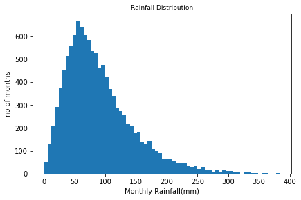

```python
fig,axes = plt.subplots()
fig.tight_layout()
fig.set_size_inches(400/screen_dpi, 250/screen_dpi)

axes.hist(df_tidy['Rainfall'], bins='auto')
axes.set_xlabel('Monthly Rainfall(mm)')
axes.set_ylabel('no of months')
axes.set_title( 'Rainfall Distribution', fontsize=9)
```

## 4.2 Visual Analysis Process

Using DF_TIDY and the time series datasets, try to answer each of the research questions.

```python
df_tidy.groupby(['Region','Year']).sum().groupby('Region').mean().sort_values('Rainfall') # mean annual rainfall by region
df_tidy.groupby(['Region','Year']).sum().groupby('Region').agg(['min','max'])# min & max annual rainfall of a region
```

| Region | Rainfall min | Rainfall max | decade min | decade max | reg_perc_bin min | reg_perc_bin max |
| --- | --- | --- | --- | --- | --- | --- |
| East_Anglia | 346.5 | 810.1 | 22920 | 24120 | 272 | 799 |
| England_E_and_NE | 542.3 | 1043.1 | 22920 | 24120 | 363 | 812 |
| England_NW_and_N_Wales | 905.6 | 1689.2 | 22920 | 24120 | 374 | 801 |
| England_SE_and_Central_S | 406.3 | 1104.3 | 22920 | 24120 | 271 | 798 |
| England_SW_and_S_Wales | 810.2 | 1591.0 | 22920 | 24120 | 381 | 789 |
| Midlands | 540.9 | 1085.0 | 22920 | 24120 | 370 | 809 |
| Scotland_E | 779.7 | 1445.7 | 22920 | 24120 | 354 | 847 |
| Scotland_N | 1111.7 | 2137.6 | 22920 | 24120 | 380 | 798 |
| Scotland_W | 1196.7 | 2297.7 | 22920 | 24120 | 403 | 836 |

#### 4.2.1 Is overall UK rainfall increasing?

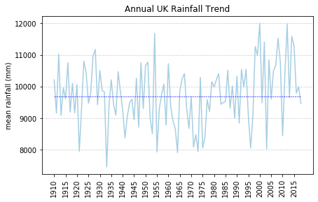

```python
# sum all the data across regions and years
stepsize=5 # x-axis every 5 years shown

columnlist=['Year','Rainfall']
temp=df_tidy[columnlist].groupby('Year').sum()
temp['Median']=temp.median().median()
temp=temp.transpose()

# overview visualisations
fig, ax = plt.subplots()
fig.set_size_inches(500/screen_dpi, 300/screen_dpi)
start, end = ax.get_xlim()
colour=0 # colour index for each region
ax.plot(temp.columns, temp.loc['Rainfall'], color=clust_colors[colour], label=temp.loc['Rainfall'].name)#, color='#00000080'
ax.plot(temp.loc['Median'], color='blue',linestyle='--', linewidth=0.6, alpha=1, label='median')
#ax.plot(interval_median, color='red') # shows mean of all years,regions on graph

ax.yaxis.grid(color='#D0D0D0', linestyle='--')
start, end = 1910,2020
ax.set_xticks(np.arange(start, end, stepsize))

plt.xticks(rotation=90)
plt.ylabel('mean rainfall (mm)')
#plt.legend( title='Regions')
plt.title('Annual UK Rainfall Trend')
plt.show()
```

This looks like overall rainfall is increasing - smooth the data by showing the mean for decades.

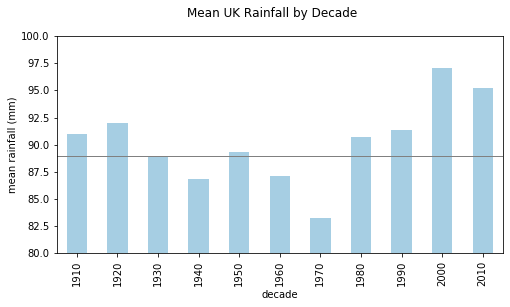

```python
columnlist=['decade','Rainfall']
temp=df_tidy[columnlist].groupby('decade').mean()
temp['Mean']=temp.mean().mean()
temp['Mean_pre_2000']=df_tidy[df_tidy["decade"]<2000].Rainfall.mean()
temp['Mean_post_2000']=df_tidy[df_tidy["decade"]>=2000].Rainfall.mean()
temp=temp.transpose()

fig = plt.figure(figsize=(8,4))
colour=0 # colour index for each region
stepsize=5 # x-axis every 5 years shown

from matplotlib.ticker import (AutoMinorLocator, MultipleLocator)

plt.ylabel('mean rainfall (mm)')
i=0
ax=plt.subplot(1,1,1)
temp.loc['Rainfall'].plot.bar(color= clust_colors[i])
ax.axhline(temp.loc['Mean_pre_2000'].mean(), color='grey', linewidth=1) # pre-2000 mean
ax.set_ylim([80,100])

fig.suptitle('Mean UK Rainfall by Decade')
plt.show()
```

Show the general pattern of rainfall for each Region over the last 100 years.

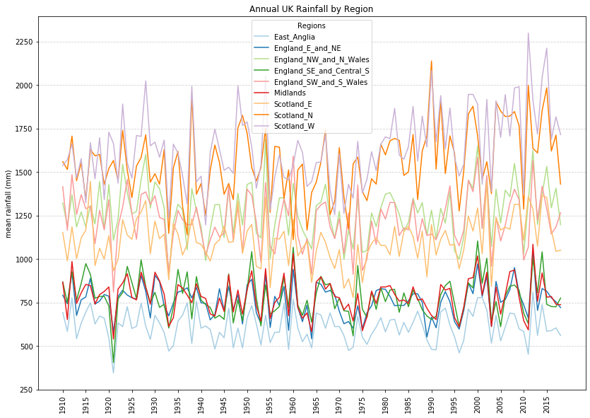

```python
# overview visualisations
fig, ax = plt.subplots()
fig.set_size_inches(1000/screen_dpi, 700/screen_dpi)
start, end = ax.get_xlim()
colour=0 # colour index for each region
for index, row in ts_year_reg_sm.iterrows():
    ax.plot(ts_year_reg_sm.columns, row, color=clust_colors[colour], label=row.name)#, color='#00000080'
    colour+=1

ax.yaxis.grid(color='#D0D0D0', linestyle='--')
start, end = 1910,2020
stepsize=5 # x-axis every 5 years shown
ax.set_xticks(np.arange(start, end, stepsize))

plt.xticks(rotation=90)
plt.ylabel('mean rainfall (mm)')
plt.legend( title='Regions')
plt.title('Annual UK Rainfall by Region')
plt.show()
```

The plot above shows that: the overall UK rainfall follows a relatively consistent pattern within and between Regions, that is, the rainfall amount varies from year to year and regions have peaks and troughs in roughtly the same years.  
The plot also shows, however that the regions have quite different amounts of rain and fall into 3 distinct bands:

1. North and West Scotland - the wettest area of the country
2. Wales, North West England and East Scotland
3. Southern UK

We will plot these regions separately below to validate this finding and show it more clearly.

The mean rainfall looks to be on an upward trend, seen particularly in the areas with higher rainfall. We will investigate this further below (?) by showing each region more clearly and visualising rainfall by decade.

##### Overall Rainfall by Regional Band

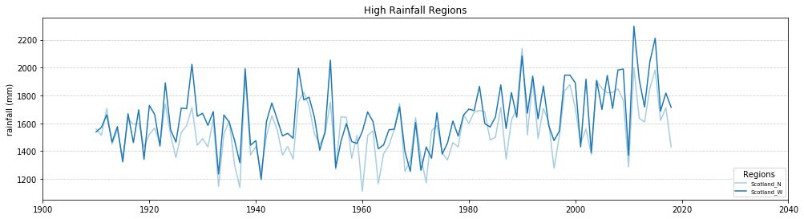

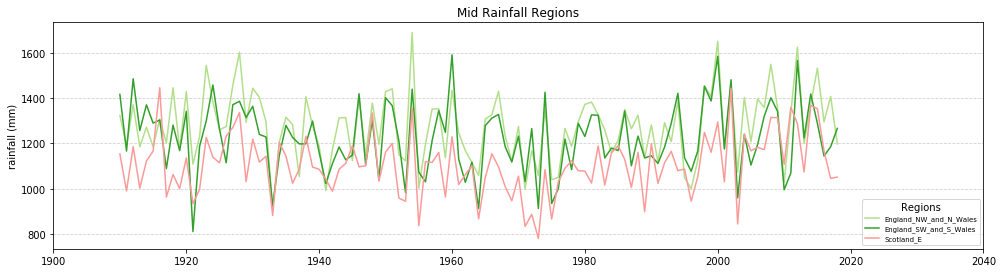

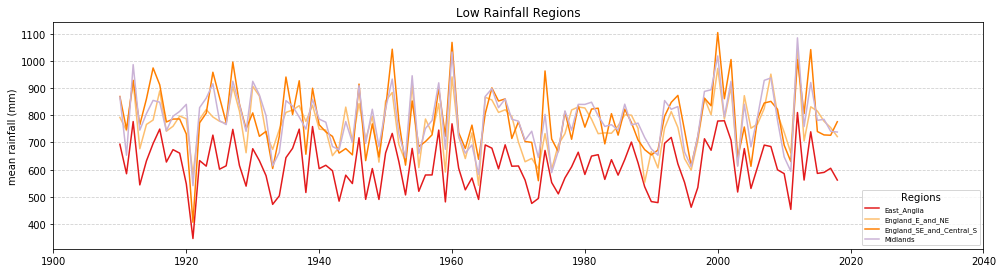

```python
colour=0 # colour index for each region

# high rainfall
fig, ax = plt.subplots()
fig.set_size_inches(1200/screen_dpi, 300/screen_dpi)
for index, row in ts_year_reg_sm.iterrows():
    if int(region_agg.loc[region_agg["Region"]==index,"Rainfall_mean"]) > int(rain_dict['mid']):
        ax.plot(ts_year_reg_mn.columns, row, color=clust_colors[colour], label=row.name)
        colour+=1

ax.yaxis.grid(color='#D0D0D0', linestyle='--')
ax.set_xticks(ax.get_xticks()[::1])
plt.ylabel('rainfall (mm)')

plt.title('High Rainfall Regions')
plt.legend( title='Regions',fontsize ='x-small', loc='lower right')
plt.show()

# mid rainfall
fig, ax = plt.subplots()
fig.set_size_inches(1200/screen_dpi, 300/screen_dpi)
for index, row in ts_year_reg_sm.iterrows():
    if ( (int(region_agg.loc[region_agg["Region"]==index,"Rainfall_mean"]) > int(rain_dict['low'])) and
        (int(region_agg.loc[region_agg["Region"]==index,"Rainfall_mean"]) < int(rain_dict['mid']))):
        ax.plot(ts_year_reg_mn.columns, row, color=clust_colors[colour], label=row.name)
        colour+=1

ax.yaxis.grid(color='#D0D0D0', linestyle='--')
ax.set_xticks(ax.get_xticks()[::1])
plt.ylabel('rainfall (mm)')
plt.title('Mid Rainfall Regions')
plt.legend( title='Regions',fontsize ='x-small', loc='lower right')
plt.show()


# low rainfall
fig, ax = plt.subplots()
fig.set_size_inches(1200/screen_dpi, 300/screen_dpi)
for index, row in ts_year_reg_sm.iterrows():
    if int(region_agg.loc[region_agg["Region"]==index,"Rainfall_mean"]) < int(rain_dict['low']):
        ax.plot(ts_year_reg_mn.columns, row, color=clust_colors[colour], label=row.name)
        colour+=1

ax.yaxis.grid(color='#D0D0D0', linestyle='--')
ax.set_xticks(ax.get_xticks()[::1])
plt.ylabel('mean rainfall (mm)')

plt.title('Low Rainfall Regions')
plt.legend( title='Regions',fontsize ='x-small', loc='lower right')
plt.show()
```

North and West Scotland have a definite upward trend since around 1990.  
Other regions also have a slight upward trend with more extreme weather events since 2000.  
We need to plot regions separately to clearly see this.

##### Overall Rainfall Region by Region

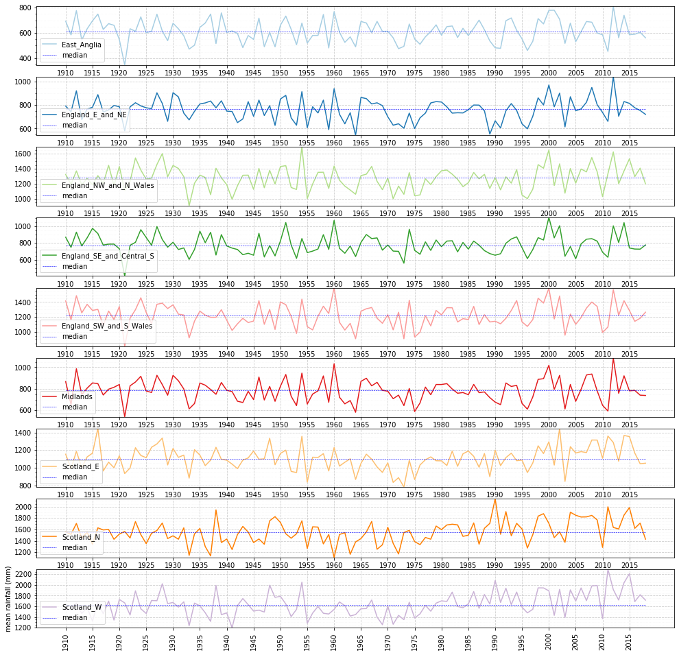

```python
# this could be sorted by high to low rainfall / or by clusters of types
# overview visualisations
fig,ax = plt.subplots(9,1,figsize=(10,25)) # create Figure fig with subplots

fig.set_size_inches(1200/screen_dpi, 1200/screen_dpi)
start, end = 1910,2020 #ax.get_xlim()
colour=0 # colour index for each region

stepsize=5 # x-axis every 5 years shown
#ax.set_xticks(ts_year_reg_mn.columns) #ts_year_reg_mn.columns
#ax.set_xticks(ax.get_xticks()[::1])

from matplotlib.ticker import (AutoMinorLocator, MultipleLocator)

plt.ylabel('mean rainfall (mm)')
i=0
for index, row in ts_year_reg_sm.iterrows():
    ax[i].plot(ts_year_reg_sm.columns, row, color=clust_colors[colour], label=row.name)#, color='#00000080'
    median_year=row.copy()
    median_year.loc[:]=row.median() # mean and median were the same so use either
    ax[i].plot(median_year, color='blue',linestyle='--', linewidth=0.6, alpha=1, label='median')
    ax[i].yaxis.grid(color='#D0D0D0', linestyle='--')
    ax[i].set_ylim(row.min(), row.max())
    ax[i].set_xticks(np.arange(start, end, 5))
    ax[i].yaxis.set_major_locator(MultipleLocator(200))
    ax[i].yaxis.set_minor_locator(AutoMinorLocator(4))
    ax[i].grid(which='major', color='#CCCCCC', linestyle='--')
    ax[i].grid(which='minor', color='#CCCCCC', linestyle=':')
    ax[i].grid(which='minor', alpha=0.2)
    plt.xticks(rotation=90)
    ax[i].legend(loc='lower left')
    colour+=1
    i+=1

plt.show()
```

The separate plots show that:  
All 3 Scottish regions are showing an upward trend.  
We will need to visualise mean rainfall for separate time bins to see this and when it started.

Scotland West and North: have had many instance of breaching previous maximum and upper percentile yearly values: we need to do some counts of these breaches for parameterised boundaries (see ?). Since 1990, W Scotland has had only 4 years with below median rainfall.

Scotland East: has not breached previous maximum values in recent year but has had rainfall in the upper percentiles many more times since 2000.

Midlands/East Anglia: no strong pattern though looks like a new historic maximum in 2012.  
NE/NW & N Wales/SW and S Wales: have had more years of high rainfall since 2000. SE no discernible upward trend though more years of high values than previously.

visualise the frequency of upper percentile breaches.

##### Overall Rainfall Upward Trend

Analyse further whether the updward trend detected in the years' overview is valid.

1. plot rainfall by decade to smooth the yearly values

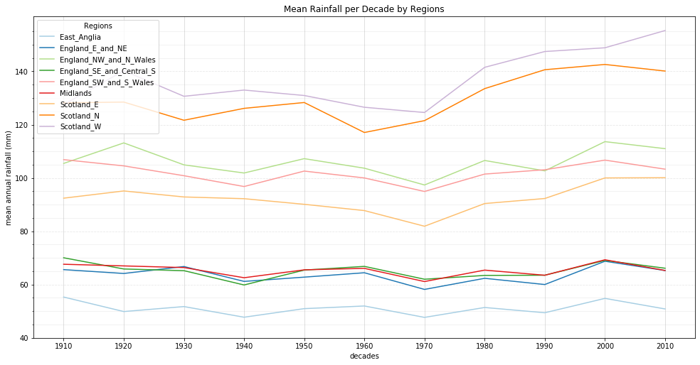

```python
# graph of mean rainfall for decades
# DO decade ds FOR k=5, 10 etc to find best view

fig, ax = plt.subplots()
fig.set_size_inches(1200/screen_dpi, 600/screen_dpi)
start, end = ax.get_xlim()
colour=0 # colour index for each region
for index, row in ts_dec_region_mn.iterrows():
    ax.plot(ts_dec_region_mn.columns, row, color=clust_colors[colour], label=row.name)#, color='#00000080'
    colour+=1

ax.yaxis.grid(color='#D0D0D0', linestyle='--')
ax.set_xticks(ts_dec_region_mn.columns) #ts_year_reg_mn.columns
minval=math.floor(ts_dec_region_mn.min().min()/10) * 10
maxval= math.ceil(ts_dec_region_mn.max().max()/10) * 10
major_ticks = np.arange(minval,maxval, 20)
minor_ticks = np.arange(minval, maxval, 5)

ax.set_yticks(major_ticks)
ax.set_yticks(minor_ticks, minor=True)

# And a corresponding grid
ax.grid(which='both')

# different settings for the grids:
ax.grid(which='minor', alpha=0.2)
ax.grid(which='major', alpha=0.5)
#ax.set_xticks(ax.get_xticks()[::1])

plt.xlabel('decades')
plt.ylabel('mean annual rainfall (mm)')
plt.legend( title='Regions', loc='upper left')
plt.title('Mean Rainfall per Decade by Regions')
plt.show()
```

```python
df_tidy.groupby(['Region','decade']).sum()#.groupby('Region').agg(['min','max'])# min & max annual rainfall of a region
(df_tidy.loc[df_tidy["decade"]>=1980].groupby(['Region','decade']).sum()/10).groupby('Region').mean() # regional mean since 1980
(df_tidy.loc[df_tidy["decade"]<1980].groupby(['Region','decade']).sum()/10).groupby('Region').mean() # regional mean before 1980
# difference in the Mean Annual rainfall in an XLS
```

| Region | Year | Rainfall | reg_perc_bin |
| --- | --- | --- | --- |
| East_Anglia | 23334.0 | 609.098571 | 590.257143 |
| England_E_and_NE | 23334.0 | 759.638571 | 589.328571 |
| England_NW_and_N_Wales | 23334.0 | 1257.627143 | 585.971429 |
| England_SE_and_Central_S | 23334.0 | 780.370000 | 592.871429 |
| England_SW_and_S_Wales | 23334.0 | 1211.158571 | 587.114286 |
| Midlands | 23334.0 | 782.222857 | 590.114286 |
| Scotland_E | 23334.0 | 1084.061429 | 580.242857 |
| Scotland_N | 23334.0 | 1493.545714 | 571.457143 |
| Scotland_W | 23334.0 | 1565.734286 | 565.928571 |

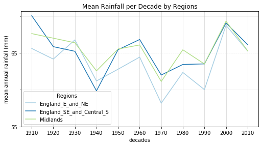

```python
# repeat the decade analysis above for the lower rainfall regions to better show any smaller increase
regionlist=['England_NW_and_N_Wales', 'England_SW_and_S_Wales']
regionlist=['Scotland_E', 'Scotland_N', 'Scotland_W']
regionlist=['East_Anglia']
regionlist=['England_E_and_NE','England_SE_and_Central_S','Midlands']
# regionlist=['East_Anglia'] # rise after a dry period but not beyond previous high values
temp=ts_dec_region_mn.loc[ts_dec_region_mn.index.isin(regionlist)]

fig, ax = plt.subplots()
fig.set_size_inches(600/screen_dpi, 300/screen_dpi)
start, end = ax.get_xlim()
colour=0 # colour index for each region
for index, row in temp.iterrows():
    ax.plot(temp.columns, row, color=clust_colors[colour], label=row.name)#, color='#00000080'
    colour+=1
minor_val=5
major_val=10
ax.yaxis.grid(color='#D0D0D0', linestyle='--')
ax.set_xticks(temp.columns) #ts_year_reg_mn.columns
minval=math.floor(temp.min().min()/minor_val) * minor_val
maxval= math.ceil(temp.max().max()/minor_val) * minor_val
major_ticks = np.arange(minval,maxval, major_val)
minor_ticks = np.arange(minval, maxval, minor_val)

ax.set_yticks(major_ticks)
ax.set_yticks(minor_ticks, minor=True)

# And a corresponding grid
ax.grid(which='both')

# different settings for the grids:
ax.grid(which='minor', alpha=0.2)
ax.grid(which='major', alpha=0.5)
#ax.set_xticks(ax.get_xticks()[::1])

plt.xlabel('decades')
plt.ylabel('mean annual rainfall (mm)')
plt.legend( title='Regions', loc='lower left')
plt.title('Mean Rainfall per Decade by Regions')
plt.show()
```

##### Regional Rainfall Statistics by Decade

```python
# bar charts of 5/10/n year periods of mean rainfall per region
# populate a column of year-bins, group and use to create year bin time series

year_bin=10 # 5
temp=df_tidy[['Year','Region','Rainfall']]
temp['year_bin'] = np.floor(temp['Year'] / year_bin) * year_bin
yearbin_region_agg = temp.reset_index(drop=False)[['year_bin','Region','Rainfall']].groupby(['year_bin','Region']).mean()

target_col = 'Rainfall'
# This unstack command retains the first level of our index (cell_id) and pivots the values of the target column (Count) into columns defined by values of the second index level ('interval', zero-based level index)
ts_yearbin_reg_mn = yearbin_region_agg[target_col].unstack(level=0)

yearbin_region_agg.head(10)
ts_yearbin_reg_mn.head(10)
```

| year_bin Region | 1910.0 | 1920.0 | 1930.0 | 1940.0 | 1950.0 | 1960.0 | 1970.0 | 1980.0 | 1990.0 | 2000.0 | 2010.0 |
| --- | --- | --- | --- | --- | --- | --- | --- | --- | --- | --- | --- |
| East_Anglia | 55.317500 | 49.875000 | 51.746667 | 47.750000 | 50.969167 | 51.963333 | 47.685833 | 51.399167 | 49.427500 | 54.812500 | 50.855556 |
| England_E_and_NE | 65.605833 | 64.160000 | 66.769167 | 61.189167 | 62.786667 | 64.430833 | 58.180833 | 62.347500 | 60.017500 | 68.745833 | 65.269444 |
| England_NW_and_N_Wales | 105.447500 | 113.144167 | 104.910833 | 101.853333 | 107.238333 | 103.658333 | 97.363333 | 106.555833 | 102.663333 | 113.619167 | 110.987963 |
| England_SE_and_Central_S | 70.048333 | 65.848333 | 65.219167 | 59.849167 | 65.430833 | 66.820000 | 62.000000 | 63.430000 | 63.508333 | 69.065833 | 66.130556 |
| England_SW_and_S_Wales | 106.865833 | 104.525000 | 100.835833 | 96.781667 | 102.575000 | 99.998333 | 94.927500 | 101.451667 | 103.075833 | 106.690833 | 103.298148 |
| Midlands | 67.620000 | 67.000000 | 66.378333 | 62.563333 | 65.528333 | 66.079167 | 61.127500 | 65.425000 | 63.496667 | 69.308333 | 65.287037 |
| Scotland_E | 92.412500 | 95.118333 | 92.867500 | 92.216667 | 90.110000 | 87.759167 | 81.885000 | 90.397500 | 92.288333 | 100.006667 | 100.087037 |
| Scotland_N | 128.166667 | 128.469167 | 121.645000 | 126.107500 | 128.298333 | 117.049167 | 121.499167 | 133.511667 | 140.601667 | 142.576667 | 140.101852 |
| Scotland_W | 127.530833 | 140.214167 | 130.634167 | 132.971667 | 130.929167 | 126.516667 | 124.548333 | 141.500000 | 147.430833 | 148.833333 | 155.302778 |

##### 4.2.2 'Extreme' Weather Events

To investigate whether there has been an increase in 'extreme' rainfall, visualise a heatmap of these events - defined as a count of months where rainfall exceeds an adjustable parameter percentile.  
We start with an analysis by decade for a broad picture of any trends.

```python
# create a decade-region time series with the count of 'extreme weather events - to visualise on a heatmap
k_dec=90 # defines the percentile of an 'extreme' event

dec_region_perc = df_tidy.loc[df_tidy["reg_perc_bin"] >= k_dec].reset_index(drop=False)[['decade','Region','reg_perc_bin']].groupby(['decade','Region']).count()
dec_region_perc.sort_values('reg_perc_bin').head()

# create a ts_year_reg_perc_count df (year v region: extreme event count)
target_col = 'reg_perc_bin'
ts_dec_reg_perc_count = dec_region_perc[target_col].unstack(level=0,fill_value=0)
ts_dec_reg_perc_count.head(10)
```

| decade Region | 1910 | 1920 | 1930 | 1940 | 1950 | 1960 | 1970 | 1980 | 1990 | 2000 | 2010 |
| --- | --- | --- | --- | --- | --- | --- | --- | --- | --- | --- | --- |
| East_Anglia | 16 | 9 | 15 | 12 | 10 | 8 | 10 | 13 | 12 | 13 | 13 |
| England_E_and_NE | 10 | 14 | 16 | 13 | 11 | 13 | 8 | 10 | 5 | 20 | 11 |
| England_NW_and_N_Wales | 12 | 19 | 15 | 9 | 12 | 9 | 7 | 13 | 10 | 14 | 11 |
| England_SE_and_Central_S | 16 | 10 | 11 | 10 | 8 | 11 | 14 | 11 | 15 | 14 | 11 |
| England_SW_and_S_Wales | 17 | 14 | 12 | 10 | 10 | 6 | 13 | 12 | 12 | 14 | 11 |
| Midlands | 13 | 14 | 14 | 8 | 11 | 11 | 8 | 14 | 12 | 18 | 8 |
| Scotland_E | 16 | 12 | 12 | 9 | 12 | 5 | 6 | 9 | 13 | 20 | 17 |
| Scotland_N | 9 | 11 | 7 | 8 | 9 | 4 | 9 | 19 | 22 | 18 | 14 |
| Scotland_W | 7 | 13 | 13 | 7 | 10 | 4 | 7 | 17 | 22 | 15 | 16 |

We now analyse by year to look in more detail at the increase.

```python
# create a year-region time series with the count of 'extreme weather events

k_yr=95 # percentile parameter defining an 'extreme' event

year_region_perc = df_tidy.loc[df_tidy["reg_perc_bin"] >= k_yr].reset_index(drop=False)[['Year','Region','reg_perc_bin']].groupby(['Year','Region']).count()
year_region_perc.sort_values('reg_perc_bin').head()

# create a ts_year_reg_perc_count df (year v region: extreme event count)
target_col = 'reg_perc_bin'
ts_year_reg_perc_count = year_region_perc[target_col].unstack(level=0,fill_value=0)
ts_year_reg_perc_count.head(10)
```

| Year Region | 1910 | 1911 | 1912 | 1914 | 1915 | 1916 | 1917 | 1918 | 1919 | 1921 | 1922 | 1923 | 1924 | 1926 | 1927 | 1928 | 1929 | 1930 | 1931 | 1932 | 1934 | 1935 | 1936 | 1937 | 1938 | 1939 | 1940 | 1941 | 1943 | … |
| --- | --- | --- | --- | --- | --- | --- | --- | --- | --- | --- | --- | --- | --- | --- | --- | --- | --- | --- | --- | --- | --- | --- | --- | --- | --- | --- | --- | --- | --- | --- |
| East_Anglia | 1 | 1 | 1 | 1 | 2 | 0 | 1 | 1 | 1 | 0 | 0 | 0 | 1 | 0 | 1 | 0 | 2 | 1 | 0 | 1 | 0 | 0 | 1 | 0 | 0 | 3 | 1 | 1 | 1 | … |
| England_E_and_NE | 0 | 0 | 2 | 1 | 2 | 0 | 1 | 1 | 0 | 0 | 1 | 0 | 0 | 0 | 2 | 0 | 1 | 1 | 0 | 0 | 0 | 1 | 0 | 0 | 0 | 2 | 1 | 0 | 0 | … |
| England_NW_and_N_Wales | 0 | 1 | 0 | 1 | 1 | 1 | 2 | 2 | 0 | 1 | 0 | 1 | 0 | 0 | 1 | 2 | 2 | 1 | 1 | 1 | 0 | 2 | 0 | 0 | 1 | 1 | 1 | 0 | 0 | … |
| England_SE_and_Central_S | 0 | 1 | 1 | 1 | 1 | 0 | 1 | 1 | 0 | 0 | 0 | 1 | 0 | 1 | 1 | 1 | 2 | 0 | 0 | 1 | 1 | 1 | 0 | 1 | 0 | 3 | 1 | 0 | 1 | … |
| England_SW_and_S_Wales | 1 | 1 | 1 | 1 | 1 | 1 | 1 | 1 | 1 | 0 | 0 | 1 | 0 | 1 | 0 | 2 | 2 | 0 | 1 | 1 | 1 | 0 | 0 | 0 | 0 | 1 | 1 | 0 | 1 | … |
| Midlands | 1 | 1 | 1 | 1 | 2 | 0 | 1 | 1 | 0 | 0 | 0 | 1 | 1 | 1 | 0 | 1 | 2 | 0 | 0 | 1 | 1 | 1 | 1 | 0 | 0 | 2 | 1 | 0 | 0 | … |
| Scotland_E | 1 | 2 | 0 | 1 | 1 | 1 | 0 | 0 | 0 | 0 | 0 | 1 | 0 | 0 | 1 | 1 | 1 | 1 | 1 | 1 | 1 | 1 | 0 | 1 | 2 | 0 | 2 | 0 | 0 | … |
| Scotland_N | 0 | 0 | 1 | 0 | 0 | 2 | 2 | 0 | 0 | 2 | 0 | 1 | 0 | 0 | 0 | 1 | 1 | 0 | 0 | 1 | 0 | 1 | 1 | 0 | 2 | 0 | 0 | 0 | 0 | … |
| Scotland_W | 0 | 1 | 1 | 0 | 0 | 0 | 1 | 0 | 1 | 1 | 0 | 0 | 0 | 0 | 0 | 1 | 1 | 0 | 1 | 2 | 0 | 1 | 0 | 0 | 2 | 1 | 0 | 0 | 1 | … |

```python
# melt the extreme events into a heatmap table - set df_heatmap as YEAR or DECADE
### YEAR
df_heatmap = pd.melt(ts_year_reg_perc_count.reset_index(),id_vars=['Region'])
df_heatmap = df_heatmap.rename(columns={'Region': 'var2','Year': 'var1'})
k=k_yr
### DECADE
df_heatmap = pd.melt(ts_dec_reg_perc_count.reset_index(),id_vars=['Region'])
df_heatmap = df_heatmap.rename(columns={'Region': 'var2','decade': 'var1'})
k=k_dec
print('dec:',k_dec,'year:',k_yr) # extreme parameter
df_heatmap.sort_values('var1').head()
```

```
dec: 90 year: 95
```

|  | var2 | var1 | value |
| --- | --- | --- | --- |
| 0 | East_Anglia | 1910 | 16 |
| 1 | England_E_and_NE | 1910 | 10 |
| 2 | England_NW_and_N_Wales | 1910 | 12 |
| 3 | England_SE_and_Central_S | 1910 | 16 |
| 4 | England_SW_and_S_Wales | 1910 | 17 |

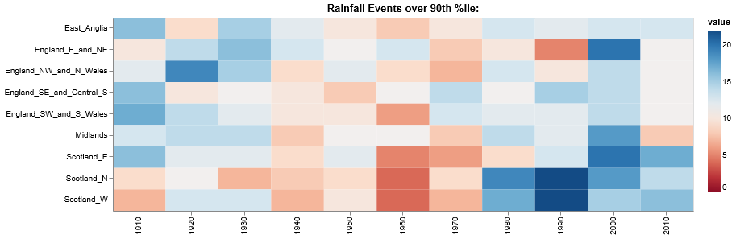

```python
# visualise a heatmap
# this will create a heatmap for dataframe df_heatmap with columns var1,var2,value
# this table is created above for a choice of years/decades and for various parameters k representing
# the percentile rainfall classed as an extreme event (eg. 90=90th %ile and over)
min=0
max=int(df_heatmap.value.max())

base = alt.Chart(df_heatmap).encode(
    x=alt.X('var1:O',scale=alt.Scale(paddingInner=0),sort=alt.EncodingSortField('index:', order='ascending')),
    y=alt.Y('var2:N',scale=alt.Scale(paddingInner=0),sort=alt.EncodingSortField('index:', order='ascending')),
).properties(
    title='Rainfall Events over '+str(k)+'th %ile:'
)

heatmap = base.mark_rect().encode(
    color=alt.Color('value:Q', scale=alt.Scale(domain=[min,max],scheme='redblue')),
    tooltip=['value:Q','var2:N','var1:O']
    )

text = base.mark_text(baseline='middle').encode(
   # alt.Text('value',format='.2f'),# text in grid - remove if not required
    color=alt.value('white'),
    tooltip=['value:Q','var2:N','var1:O']
)

(heatmap + text).properties(width=720,height=240).configure_axis(title=None)
```

For all parameters tried, pre-1950 there is a wide distribution of counts, then follows (1950-1980) some years with low/zero counts then from 1998 there is small but significant increase in high rainfall events across all regions but especially in N & W Scotland.

Analysing by decade (k=90,95), there is a clear increase in 'extreme' rainfall events for Scotland (N&W since 1980s, E since 2000s), the Midlands and NE England (during the 2000s but not since). This is the case for 90th and 95th %ile.

NW & SW ENgland and Wales do not appear to be having more frequent extreme events. **Visualise this in more details in bar charts**

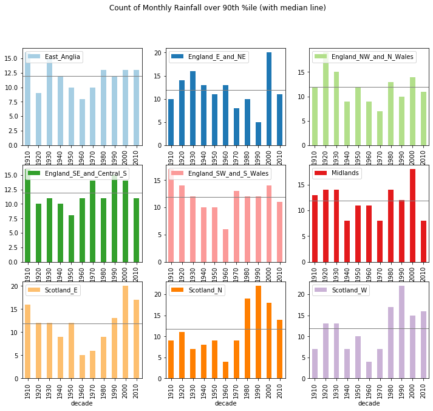

```python
# bar charts of extreme events - parameters set above
# can be run for any df by setting temp df
temp = ts_year_reg_perc_count # set the df to be plotted
k=k_yr
temp = ts_dec_reg_perc_count # set the df to be plotted
k=k_dec

fig = plt.figure(figsize=(12,10))
colour=0 # colour index for each region
stepsize=5 # x-axis every 5 years shown

from matplotlib.ticker import (AutoMinorLocator, MultipleLocator)

region_sub=['Scotland_E','Scotland_N','Scotland_W','England_E_and_NE','Midlands']

plt.ylabel('mean rainfall (mm)')
i=0
for index, row in temp.iterrows():
    ax=plt.subplot(3,3,i+1)
    row.plot.bar(color= clust_colors[i])
    ax.axhline(row.mean(), color='grey', linewidth=1)
    ax.legend(loc='upper left')
    colour+=1
    i+=1

fig.suptitle('Count of Monthly Rainfall over '+str(k)+'th %ile (with median line) ')
plt.show()
```

##### Regional Extreme Event Statistics by Decade

```python
# compare the means of extreme counts, before and after 1980
temp = df_tidy.loc[df_tidy["reg_perc_bin"] >= k,["decade","Region","reg_perc_bin"]] # filter percentiles > k
print(temp.loc[temp["decade"]<1980].groupby(['Region','decade']).count().groupby(['Region']).mean().sort_values('Region')) # filter decades before 1980
print(temp.loc[temp["decade"]>=1980].groupby(['Region','decade']).count().groupby(['Region']).mean().sort_values('Region')) # filter decades over 1980
```

```
                          reg_perc_bin
Region
East_Anglia                  11.428571
England_E_and_NE             12.142857
England_NW_and_N_Wales       11.857143
England_SE_and_Central_S     11.428571
England_SW_and_S_Wales       11.714286
Midlands                     11.285714
Scotland_E                   10.285714
Scotland_N                    8.142857
Scotland_W                    8.714286
                          reg_perc_bin
Region
East_Anglia                      12.75
England_E_and_NE                 11.50
England_NW_and_N_Wales           12.00
England_SE_and_Central_S         12.75
England_SW_and_S_Wales           12.25
Midlands                         13.00
Scotland_E                       14.75
Scotland_N                       18.25
Scotland_W                       17.50
```

E and NE England had an unprecedented number of high rainfall events in the 2000s Similarly, Midlands had high (record breaking) in 2000s and no pattern otherwise.  
The mean number of extreme monthly rainfalls per decade in Scotland N & W was 8 before 1980 and 18 after. E Scotland 10 before and 14 since 1980 (rise here started in 2000). Other regions no discernible pattern.

##### 4.2.3 Investigate the Yearly Cycle

To investigate the cyclical nature of the rainfall over each year we first show the monthly mean for a region over the whole year time period.

```python
ts_mth_region_mn.head()
```

| month_no Region | 1 | 2 | 3 | 4 | 5 | 6 | 7 | 8 | 9 | 10 | 11 | 12 |
| --- | --- | --- | --- | --- | --- | --- | --- | --- | --- | --- | --- | --- |
| East_Anglia | 53.799083 | 40.279817 | 41.441284 | 42.597248 | 46.043119 | 48.035780 | 55.871560 | 57.466972 | 51.653211 | 57.455963 | 61.833028 | 56.422018 |
| England_E_and_NE | 71.296330 | 54.319266 | 52.894495 | 50.372477 | 54.680734 | 57.297248 | 66.165138 | 74.284404 | 61.597248 | 70.555963 | 76.229358 | 73.216514 |
| England_NW_and_N_Wales | 129.477064 | 96.058716 | 88.557798 | 74.372477 | 77.625688 | 80.865138 | 96.423853 | 112.277064 | 111.322018 | 131.508257 | 134.926606 | 139.623853 |
| England_SE_and_Central_S | 79.211009 | 56.868807 | 54.577982 | 51.341284 | 53.534862 | 50.477064 | 57.378899 | 63.621101 | 62.733028 | 80.952294 | 86.774312 | 84.992661 |
| England_SW_and_S_Wales | 133.962385 | 97.090826 | 89.070642 | 72.800917 | 75.314679 | 70.613761 | 84.022936 | 97.591743 | 96.122018 | 126.781651 | 136.020183 | 143.392661 |

```python
temp
```

|  | Year | Region | month_no | Rainfall | decade | reg_perc_bin |
| --- | --- | --- | --- | --- | --- | --- |
| 6 | 1916 | Scotland_N | 1 | 266.7 | 1910 | 96 |
| 10 | 1920 | Scotland_N | 1 | 224.9 | 1920 | 91 |
| 11 | 1921 | Scotland_N | 1 | 249.1 | 1920 | 95 |
| 13 | 1923 | Scotland_N | 1 | 252.8 | 1920 | 95 |
| 17 | 1927 | Scotland_N | 1 | 246.2 | 1920 | 94 |
| ... | ... | ... | ... | ... | ... | ... |
| 11732 | 1979 | East_Anglia | 12 | 95.4 | 1970 | 93 |
| 11742 | 1989 | East_Anglia | 12 | 104.1 | 1980 | 96 |
| 11755 | 2002 | East_Anglia | 12 | 99.5 | 2000 | 95 |
| 11765 | 2012 | East_Anglia | 12 | 97.9 | 2010 | 95 |
| 11770 | 2017 | East_Anglia | 12 | 89.9 | 2010 | 91 |

1178 rows × 6 columns

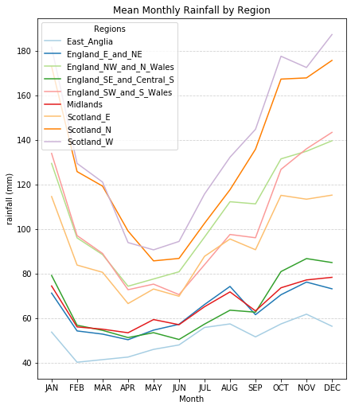

```python
# create a temp df with the display month names
temp=ts_mth_region_mn
temp=temp.rename(columns=month_dict_disp)

# monthly cyclical rainfall
fig, ax = plt.subplots()
fig.set_size_inches(500/screen_dpi, 600/screen_dpi)
start, end = ax.get_xlim()

colour=0 # colour index for each region
for index, row in temp.iterrows():
    ax.plot(temp.columns, row, color=clust_colors[colour], label=row.name)#, color='#00000080'
    colour+=1

ax.yaxis.grid(color='#D0D0D0', linestyle='--')

plt.xlabel('Month')
plt.ylabel('rainfall (mm)')
plt.legend( title='Regions')
plt.title('Mean Monthly Rainfall by Region')
plt.show()
```

The annual rainfall varies fairly consistently by monthly mean across all Regions, with highs in Winter and lows in Spring and Summer.  
As previously seen, the regions fall into bands of high, mid and low rainfall and this vis shows that the annual cycle within a band is consistent across regions.

High rainfall occurs in November to January in all regions.

However the driest months differ between areas of high to mid rainfall and those with lower: Scotland and the Western areas of England have least in April to June, while the South and East minimums are from February to June.  
East Anglia, the area of lowest rainfall overall, has minimum rainfall in Feb - April.  
Drill down by plotting a each year's rainfall for a region.

##### Single Region Cyclical Rainfall

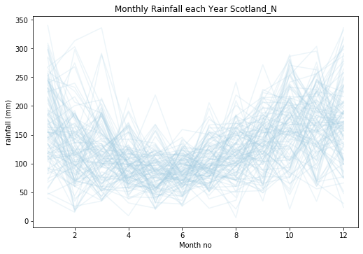

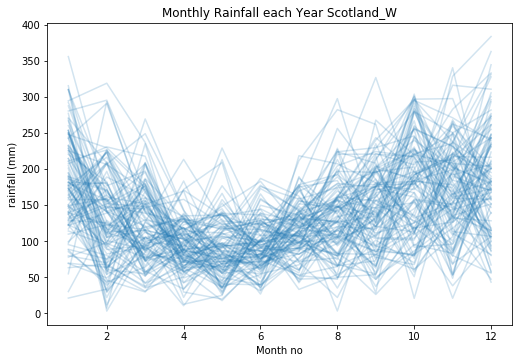

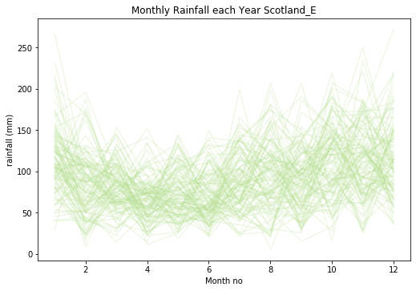

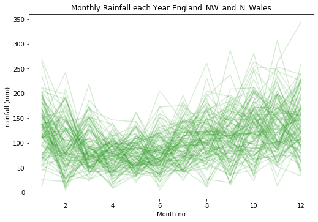

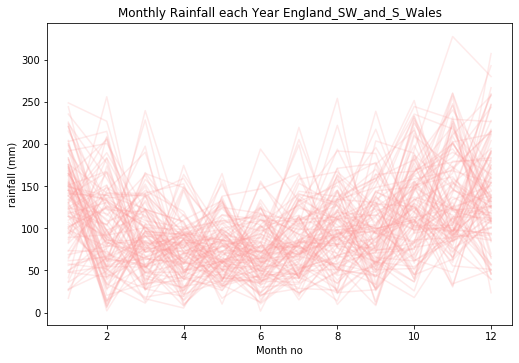

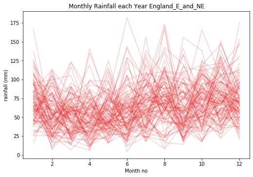

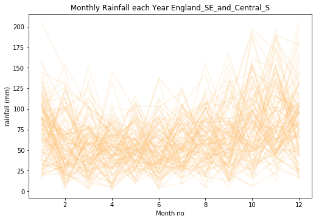

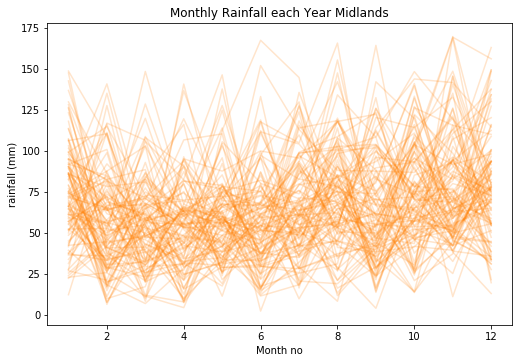

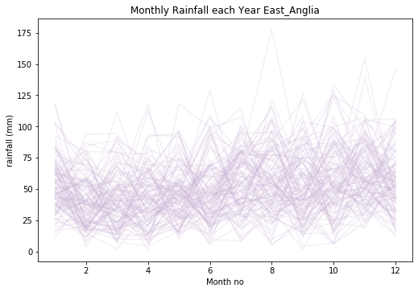

```python
# create a year-month time series for each region then plot for all years
# give unique names to the dataframes used here as they are region specific and shouldn't be picked up later
colour=0 # colour index for each regioN
for region in df_tidy['Region'].unique():
    df_tidy_regionR=df_tidy.loc[df_tidy['Region']==region]
    #pivot by month and year
    mth_year_aggR = df_tidy_regionR.reset_index(drop=False)[['Year','month_no','Rainfall']].groupby(['month_no','Year']).mean()
    mth_year_aggR .head()
    # create a time series pivot by region and month
    target_col = 'Rainfall'
    ts_mth_year_mnR = mth_year_aggR[target_col].unstack(level=0)
    # monthly cyclical rainfall - amend to show a single region plotted over all years
    fig, ax = plt.subplots()
    fig.set_size_inches(600/screen_dpi, 400/screen_dpi)
    start, end = ax.get_xlim()

    for index, row in ts_mth_year_mnR.iterrows():
        ax.plot(ts_mth_year_mnR.columns, row, color=clust_colors[colour],alpha=0.2, label=row.name)#, color='#00000080'
        #ax.yaxis.grid(color='#D0D0D0', linestyle='--')

    plt.xlabel('Month no')
    plt.ylabel('rainfall (mm)')
    #plt.legend( title='Regions')
    plt.title('Monthly Rainfall each Year '+region)
    plt.show()
    colour+=1
```

shows the picture to be more complex than shown by the mean over the entire period but not clearly showing any trends.  
Visualise on a heatmap to show a clearer picture of month-year data.

```python
def create_mth_year_agg(regionlist):
    # recreate ts_mth_year_mn time series for the df_tidy_region dataset (either all or regional subset)
    #pivot by month and year
    df_tidy_region=df_tidy.loc[df_tidy.Region.isin(regionlist)] # CREATE a working table of all or some regions so we don't overwrite the main table
    mth_year_agg = df_tidy_region.reset_index(drop=False)[['Year','month_no','Rainfall']].groupby(['month_no','Year']).mean()
    # create a time series pivot by region and month
    target_col = 'Rainfall'
    ts_mth_year_mn = mth_year_agg[target_col].unstack(level=0)
    return ts_mth_year_mn,mth_year_agg
```

```python
# create ts_mth_year_mn for any combination of regions
regionlist=df_tidy.Region.unique()    # all regions
regionlist=['England_E_and_NE','Midlands','England_SE_and_Central_S']             # subset region
regionlist=['Scotland_E']
regionlist=['England_SW_and_S_Wales','England_NW_and_N_Wales']             # subset region
regionlist=['East_Anglia']             # subset region
regionlist=['Scotland_N', 'Scotland_W']
ts_mth_year_mn,mth_year_agg=create_mth_year_agg(regionlist)
mth_year_agg.head()
ts_mth_year_mn.head()
# create a var1, var2, value table
```

| month_no Year | 1 | 2 | 3 | 4 | 5 | 6 | 7 | 8 | 9 | 10 | 11 | 12 |
| --- | --- | --- | --- | --- | --- | --- | --- | --- | --- | --- | --- | --- |
| 1910 | 171.85 | 175.30 | 98.05 | 160.90 | 96.80 | 60.75 | 120.75 | 192.00 | 56.00 | 93.75 | 154.90 | 168.1 |
| 1911 | 117.50 | 198.10 | 76.70 | 125.00 | 87.90 | 86.20 | 108.60 | 103.75 | 103.80 | 101.40 | 202.55 | 231.3 |
| 1912 | 128.40 | 115.95 | 157.95 | 108.15 | 72.15 | 136.20 | 88.70 | 141.95 | 82.45 | 159.70 | 187.95 | 304.2 |
| 1913 | 130.05 | 115.20 | 184.65 | 115.50 | 107.85 | 115.60 | 35.80 | 53.00 | 81.15 | 121.15 | 226.05 | 171.6 |
| 1914 | 157.55 | 188.45 | 149.45 | 110.25 | 88.10 | 49.10 | 96.25 | 126.05 | 91.45 | 61.50 | 210.90 | 235.8 |

```python
ts_mth_year_mn
```

| month_no Year | 1 | 2 | 3 | 4 | 5 | 6 | 7 | 8 | 9 | 10 | 11 | 12 |
| --- | --- | --- | --- | --- | --- | --- | --- | --- | --- | --- | --- | --- |
| 1910 | 171.85 | 175.30 | 98.05 | 160.90 | 96.80 | 60.75 | 120.75 | 192.00 | 56.00 | 93.75 | 154.90 | 168.10 |
| 1911 | 117.50 | 198.10 | 76.70 | 125.00 | 87.90 | 86.20 | 108.60 | 103.75 | 103.80 | 101.40 | 202.55 | 231.30 |
| 1912 | 128.40 | 115.95 | 157.95 | 108.15 | 72.15 | 136.20 | 88.70 | 141.95 | 82.45 | 159.70 | 187.95 | 304.20 |
| 1913 | 130.05 | 115.20 | 184.65 | 115.50 | 107.85 | 115.60 | 35.80 | 53.00 | 81.15 | 121.15 | 226.05 | 171.60 |
| 1914 | 157.55 | 188.45 | 149.45 | 110.25 | 88.10 | 49.10 | 96.25 | 126.05 | 91.45 | 61.50 | 210.90 | 235.80 |
| ... | ... | ... | ... | ... | ... | ... | ... | ... | ... | ... | ... | ... |
| 2014 | 232.30 | 255.70 | 153.80 | 102.20 | 115.60 | 62.00 | 96.95 | 200.15 | 42.55 | 280.40 | 136.70 | 269.40 |
| 2015 | 298.60 | 151.15 | 205.85 | 90.50 | 171.95 | 106.10 | 156.10 | 127.40 | 51.65 | 100.20 | 280.15 | 357.75 |
| 2016 | 251.15 | 196.60 | 102.35 | 104.85 | 86.15 | 83.05 | 155.15 | 140.45 | 171.80 | 62.00 | 128.70 | 171.95 |
| 2017 | 120.15 | 162.60 | 148.05 | 76.15 | 59.55 | 157.45 | 125.95 | 168.30 | 157.75 | 217.65 | 191.55 | 179.65 |
| 2018 | 219.70 | 107.55 | 89.75 | 94.25 | 52.45 | 77.90 | 90.50 | 125.10 | 202.70 | 188.65 | 170.95 | 153.40 |

109 rows × 12 columns

```python
# create a temp df with the display month names
temp=ts_mth_year_mn
temp=temp.rename(columns=month_dict_disp)

# convert ts_mth_year_mn to heatmap format var1 var2 value
df_heatmap = pd.melt(temp.reset_index(),id_vars=['Year'])
df_heatmap = df_heatmap.rename(columns={'month_no': 'var2','Year': 'var1'})
print(k) # extreme parameter
df_heatmap.sort_values('var1').head()
# show the heatmap
```

```
90
```

|  | var1 | var2 | value |
| --- | --- | --- | --- |
| 0 | 1910 | JAN | 171.85 |
| 327 | 1910 | APR | 160.90 |
| 545 | 1910 | JUN | 60.75 |
| 654 | 1910 | JUL | 120.75 |
| 218 | 1910 | MAR | 98.05 |

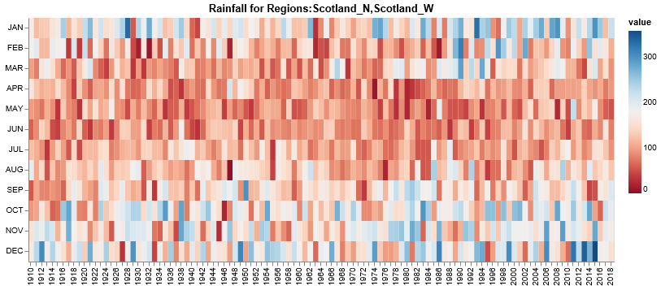

```python
# visualise a heatmap
# this will create a heatmap for dataframe df_heatmap with columns var1,var2,value
# this table is created above for a choice of years/decades and for various parameters k representing
# the percentile rainfall classed as an extreme event (eg. 90=90th %ile and over)
min=0
max=int(df_heatmap.value.max())

base = alt.Chart(df_heatmap).encode(
    x=alt.X('var1:O',scale=alt.Scale(paddingInner=0),sort=alt.EncodingSortField('index:', order='ascending')),
    y=alt.Y('var2:N',scale=alt.Scale(paddingInner=0),sort=alt.EncodingSortField('index:', order='ascending')),
).properties(
    title='Rainfall for Regions:' + ','.join(regionlist)
)

heatmap = base.mark_rect().encode(
    color=alt.Color('value:Q', scale=alt.Scale(domain=[min,max],scheme='redblue')),
    tooltip=['value:Q','var2:N','var1:O']
    )

text = base.mark_text(baseline='middle').encode(
   # alt.Text('value',format='.2f'),# text in grid - remove if not required
    color=alt.value('white'),
    tooltip=['value:Q','var2:N','var1:O']
)

(heatmap + text).properties(width=720,height=300).configure_axis(title=None)
```

1. N & W Scotland - there is some evidence that the high rainfall period is starting earlier (August when previously September) and finishing later (March rather than February). This may account partially for the overall increased rainfall in these regions.  
   No discernible pattern can be seen for other regional bands.

##### Clustering the year-month data

We will do K-Means clusters of the data to see if we can detect more meaningful patterns:

1. K-Means cluster for all regions:  
   1a. We attempt to find an appropriate number of clusters, by plotting Inertias below, but no meaningful results were obtained.  
   1b. Try clustering for 3-4-5. As no meaninful clusters were detected for all regions, we repeat the analysis for the regional bands seen above.
2. K-Means cluster for Scotland-N:  
   2a. Again no meaningful cluster number is obtained from an Inertia plot 2b. We cluster for 3-4-5 and comment on the results.

Conclusion: The clusters for all regions' Rainfall give meaningful plots of different annual cycles but the years in which they are observed do not appear to be anything other than random.  
However, note the results for Scotland-N in 3 clusters: clusters are showing 2 which have higher winter rainfall than the remaining cluster and the year calendar shows that these 2 clusters have become more prevalent recently.

```python
# this code creates df_tidy_region for all regions or regional subsets
# amend the value of 'region' to change the filter

#region=['Scotland_N']             # single region
#region=df_tidy.Region.unique()    # all regions
region=['Scotland_N','Scotland_W'] # subset of regions
ts_mth_year_mn,mth_year_agg=create_mth_year_agg(region)# execute the function to create ts_mth_year_mn
mth_year_agg
#ts_mth_year_mn
```

| month_no | Year | Rainfall |
| --- | --- | --- |
| 1 | 1910 | 171.85 |
|  | 1911 | 117.50 |
|  | 1912 | 128.40 |
|  | 1913 | 130.05 |
|  | 1914 | 157.55 |
| ... | ... | ... |
| 12 | 2014 | 269.40 |
|  | 2015 | 357.75 |
|  | 2016 | 171.95 |
|  | 2017 | 179.65 |
|  | 2018 | 153.40 |

1308 rows × 1 columns

```python
# this code will use the last ts_mth_year_mn to be created above so be careful which REGIONS are included.
# See whether clustering of years' monthly trends yields any meaningful groupings
from sklearn.preprocessing import normalize
from sklearn.cluster import KMeans

data_to_cluster = ts_mth_year_mn
#data_to_cluster = normalize(data_to_cluster) # leave this out for now

#computing K-Means with K clusters
n_clusters=3
km_model = KMeans(init='random', n_clusters=n_clusters, n_init=10)
km_model.fit_predict(data_to_cluster) # data_to_cluster is the array of year/month variables
cluster_results = km_model.labels_ # cluster_results is a vector of 0,1, .. k-1 results

# show the results
# for i, cluster_label in enumerate(cluster_results):
#    print(i,"Cluster result: ", cluster_label, " Years: ",ts_mth_year_mn.index[i])
print('clusters=',n_clusters)
data_to_cluster
```

```
clusters= 3
```

| month_no Year | 1 | 2 | 3 | 4 | 5 | 6 | 7 | 8 | 9 | 10 | 11 | 12 |
| --- | --- | --- | --- | --- | --- | --- | --- | --- | --- | --- | --- | --- |
| 1910 | 171.85 | 175.30 | 98.05 | 160.90 | 96.80 | 60.75 | 120.75 | 192.00 | 56.00 | 93.75 | 154.90 | 168.10 |
| 1911 | 117.50 | 198.10 | 76.70 | 125.00 | 87.90 | 86.20 | 108.60 | 103.75 | 103.80 | 101.40 | 202.55 | 231.30 |
| 1912 | 128.40 | 115.95 | 157.95 | 108.15 | 72.15 | 136.20 | 88.70 | 141.95 | 82.45 | 159.70 | 187.95 | 304.20 |
| 1913 | 130.05 | 115.20 | 184.65 | 115.50 | 107.85 | 115.60 | 35.80 | 53.00 | 81.15 | 121.15 | 226.05 | 171.60 |
| 1914 | 157.55 | 188.45 | 149.45 | 110.25 | 88.10 | 49.10 | 96.25 | 126.05 | 91.45 | 61.50 | 210.90 | 235.80 |
| ... | ... | ... | ... | ... | ... | ... | ... | ... | ... | ... | ... | ... |
| 2014 | 232.30 | 255.70 | 153.80 | 102.20 | 115.60 | 62.00 | 96.95 | 200.15 | 42.55 | 280.40 | 136.70 | 269.40 |
| 2015 | 298.60 | 151.15 | 205.85 | 90.50 | 171.95 | 106.10 | 156.10 | 127.40 | 51.65 | 100.20 | 280.15 | 357.75 |
| 2016 | 251.15 | 196.60 | 102.35 | 104.85 | 86.15 | 83.05 | 155.15 | 140.45 | 171.80 | 62.00 | 128.70 | 171.95 |
| 2017 | 120.15 | 162.60 | 148.05 | 76.15 | 59.55 | 157.45 | 125.95 | 168.30 | 157.75 | 217.65 | 191.55 | 179.65 |
| 2018 | 219.70 | 107.55 | 89.75 | 94.25 | 52.45 | 77.90 | 90.50 | 125.10 | 202.70 | 188.65 | 170.95 | 153.40 |

109 rows × 12 columns

Plot the month-year rainfall for each cluster

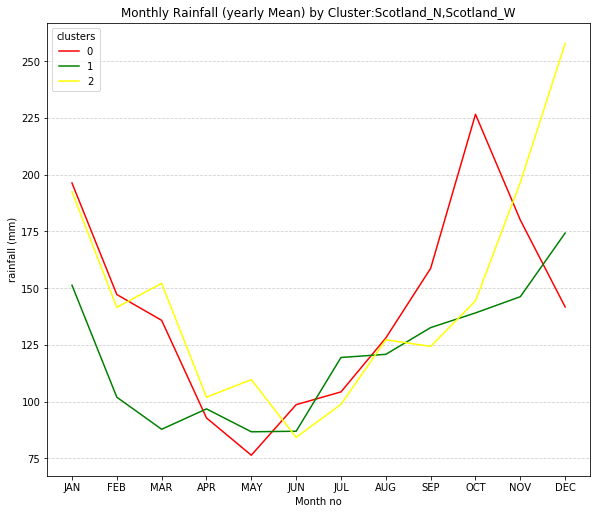

```python
# change the title to ALL when all regions

from termcolor import colored
clust_termcolor = ['red','green','yellow','blue','magenta','cyan','grey','white']

# summarise the year-month df by the clusterids
ts_mth_year_mn_clust=pd.concat([data_to_cluster.reset_index(),pd.DataFrame(cluster_results)],axis=1).rename(columns={0: 'cluster'})
temp=ts_mth_year_mn_clust.iloc[:,1::].groupby('cluster').mean() # df to graph

# change columns to month names
temp=temp.rename(columns=month_dict_disp)

# plot
fig, ax = plt.subplots()
fig.set_size_inches(700/screen_dpi, 600/screen_dpi)
start, end = ax.get_xlim()

colour=0 # colour index for each region
for index, row in temp.iterrows():
    ax.plot(temp.columns, row, color=clust_termcolor[colour], label=row.name)#, color='#00000080'
    colour+=1

ax.yaxis.grid(color='#D0D0D0', linestyle='--')

plt.xlabel('Month no')
plt.ylabel('rainfall (mm)')
plt.legend( title='clusters')
seperator=','
plt.title('Monthly Rainfall (yearly Mean) by Cluster:'+seperator.join(region))
plt.show()
```

Show the temporal pattern (years) in each cluster

```python
# try to visualise the years by cluster c
clust_termcolor = ['red','green','yellow','blue','magenta','cyan','grey','white']

for i in ts_mth_year_mn_clust.index:
    print(colored(ts_mth_year_mn_clust.Year[i], clust_termcolor[ts_mth_year_mn_clust.cluster[i]]), end =" ")
    if (ts_mth_year_mn_clust.Year[i]+1)%10==0:
        print('\n')
print("\n\n")
```

```
1910 1911 1912 1913 1914 1915 1916 1917 1918 1919

1920 1921 1922 1923 1924 1925 1926 1927 1928 1929

1930 1931 1932 1933 1934 1935 1936 1937 1938 1939

1940 1941 1942 1943 1944 1945 1946 1947 1948 1949

1950 1951 1952 1953 1954 1955 1956 1957 1958 1959

1960 1961 1962 1963 1964 1965 1966 1967 1968 1969

1970 1971 1972 1973 1974 1975 1976 1977 1978 1979

1980 1981 1982 1983 1984 1985 1986 1987 1988 1989

1990 1991 1992 1993 1994 1995 1996 1997 1998 1999

2000 2001 2002 2003 2004 2005 2006 2007 2008 2009

2010 2011 2012 2013 2014 2015 2016 2017 2018
```

Below we tried a plot of the Inertia values to determine the appropriate number of clusters but the graph shows no signs of flattening, even up to k=80.  
We now try 3, 4 and 5 clusters. All show reasonable plots of their annual cycle but the yearly distribution of the clusters does not show anything particularly meaningful except for Scotland N & W.

so we conclude that there is no meaningful clustering of the annual cycle and that each year has a randomly distribution of monthly rainfall.  
Future work could extend this analysis to look at seasonal patterns.

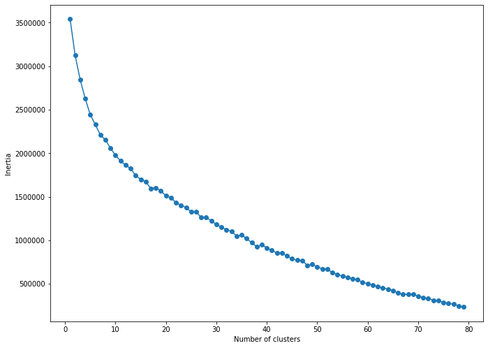

```python
# work out how many clusters is ideal
# this is giving no definitive results even up to 80 and for single regions
inertias = []
for i in range(1, 80):
    km = KMeans( n_clusters=i)
    km.fit(data_to_cluster)
    inertias.append(km.inertia_)
# inertias is a column vector of the k-means'inertias'
# inertia_ = Sum of squared distances of samples to their closest cluster center.

# plot
plt.plot(range(1, 80), inertias, marker='o')
plt.xlabel('Number of clusters')
plt.ylabel('Inertia')
plt.show()
```